# Final Project

2024-04-21

**Loading Libraries**

```r
# Loading libraries
library(readr)
library(dplyr)
library(scales)
library(tidyverse)
library(ggplot2)
library(cluster)
```

# 1 Part 1. Data cleaning / clustering

For this section, we provide the data set synthetic_data.csv, which is a synthetic data set.

## 1.1 i. Prepare the data set to maximize the expected performnce of clustering algorithm trained on the data set.

**Data Loading and Initial Exploration**

```r
# Loading the data
data <- read.csv('synthetic_data.csv')

head(data)
```

```
##   index         id       col1      col2     col3     col4        col5     col6
## 1     0  sample791 -1.0127267 -9.844298 28.13850 48.56455  0.06687684 28.13850
## 2     1  sample357 -0.8062087 -7.893232 65.10371 40.06916 -0.04496932 65.10371
## 3     2   sample89 -1.2510168 -5.348877       NA 68.86510  0.12633435 50.78602
## 4     3  sample775 -0.9206846 -5.970598 69.65227 51.06755  0.09357949 69.65227
## 5     4 sample1010 -0.9854500 -5.958759 49.68913 48.16239 -0.02473636 49.68913
## 6     5 sample1392 -1.3400522 -5.073025 78.86590 65.93620  0.04361363 78.86590
```

We notice that column 3 and 6 look very similar.

**Data Cleaning**

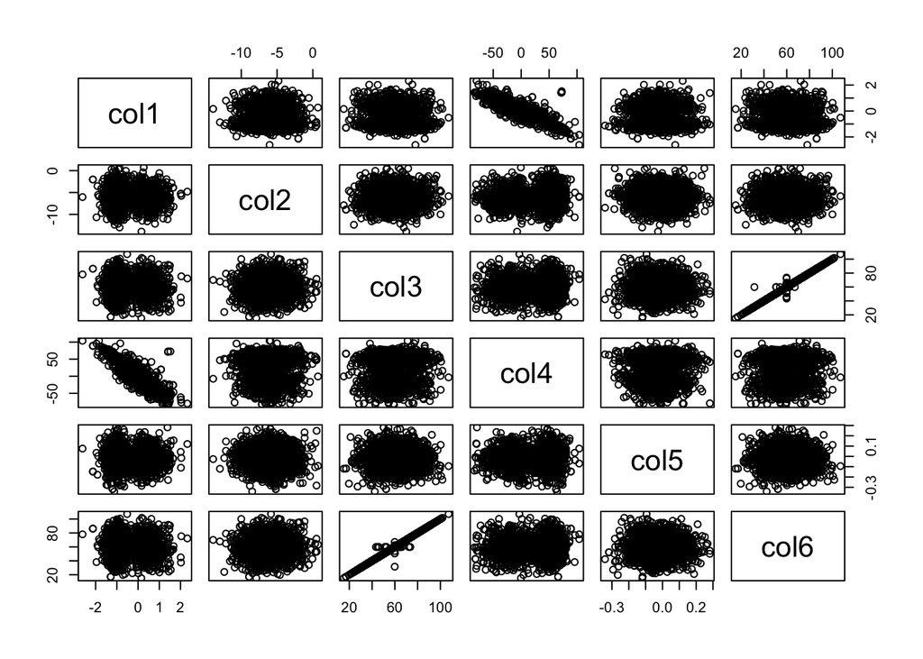

```r
# Handling missing values by replacing them with the median of their columns
data <- data %>%
  mutate(across(where(is.numeric), ~ifelse(is.na(.), median(., na.rm = TRUE), .)))

pairs(data[,3:8])
```

Col1 and col 4 seem to have a negative correlation.

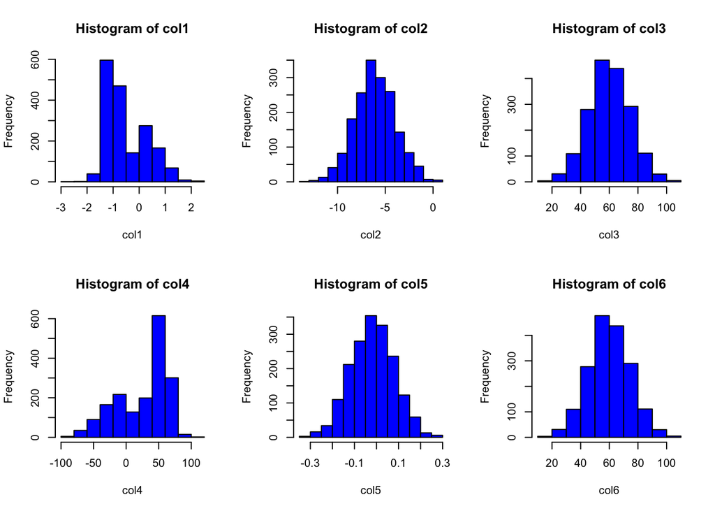

```r
# Plot each column
par(mfrow=c(2,3))
hist(data$col1, main="Histogram of col1", xlab="col1", c='blue')
hist(data$col2, main="Histogram of col2", xlab="col2", c='blue')
hist(data$col3, main="Histogram of col3", xlab="col3", c='blue')
hist(data$col4, main="Histogram of col4", xlab="col4", c='blue')
hist(data$col5, main="Histogram of col5", xlab="col5", c='blue')
hist(data$col6, main="Histogram of col6", xlab="col6", c='blue')
```

We observed that columns 3 and 6 are nearly identical and when looking at each data point we can confirm this. Therefore, we will remove column 6 from our analysis.

Additionally, columns 2, 3, and 5 appear to follow a normal distribution, suggesting that the data in these columns might have been randomly generated.

Column 1 and 4 also seem to have a negative correlation.

**Data Reduction**

```r
# Removing 'index' and 'id'
data_cleaned <- select(data, -index, -id, -col6)

# Removing duplicate rows
data_cleaned <- distinct(data_cleaned)
```

**Normalization**

```r
# Scaling the data
data_normalized <- as.data.frame(scale(data_cleaned))
```

## 1.2 ii. Building a model to cluster the data set

**Determing Optimal Number of Clusters**

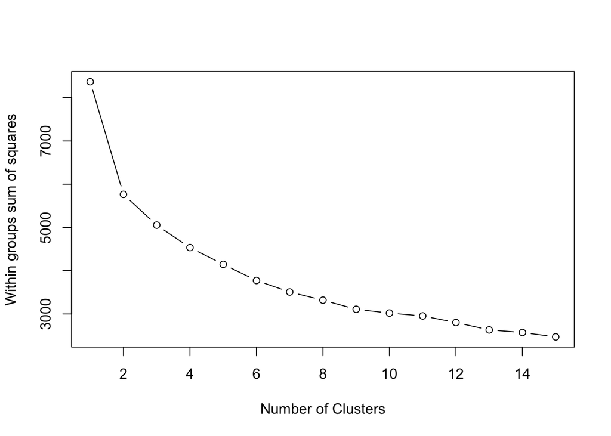

```r
# Using the elbow method to determine the optimal number of clusters
wss <- (nrow(data_normalized)-1)*sum(apply(data_normalized,2,var))
for (i in 2:15) {
  wss[i] <- sum(kmeans(data_normalized, centers=i)$withinss)
}

# Plotting the wss by num of clusters
plot(1:15, wss, type="b", xlab="Number of Clusters", ylab="Within groups sum of squares")
```

After applying the elbow method to the WSS plot, the optimal number of clusters is chosen to be 2. This is where the rate of decrease in WSS seems to slow down, indicating that additional clusters beyond this point do not significantly improve the variance explained by the model.

*K-Means Clustering without PCA*

```r
# Seed
set.seed(57)

# Clustering into 2 clusters using kmeans
kmeans_result <- kmeans(data_normalized, centers=2)

# cluster sizes
cat("Cluster sizes:\n")
```

```
## Cluster sizes:
```

```r
print(table(kmeans_result$cluster))
```

```
##
##    1    2
##  604 1071
```

```r
# means of each variable within each cluster
cat("\nCluster means:\n")
```

```
##
## Cluster means:
```

```r
aggregate(data_normalized, by=list(cluster=kmeans_result$cluster), FUN=mean)
```

```
##   cluster       col1        col2        col3       col4        col5
## 1       1  1.1759079 -0.04328456 -0.05054024 -1.1701164 -0.03513176
## 2       2 -0.6631638  0.02441071  0.02850262  0.6598976  0.01981287
```

The k-means clustering yielded two clusters with sizes of 604 for Cluster 1 and 1071 for Cluster 2. This presents a somewhat unbalanced distribution, with Cluster 2 containing nearly twice as many points as Cluster 1.

Key points are

- Cluster 1 is characterized by high values in col1 and correspondingly low values in col4. This trend shows the inverse relationship between these two variables, where col1 serves as a dominant feature. This cluster represents the conditions where the influence of col1 is significant and suppresses the values of col4.
- Cluster 2 displays low values in col1 and higher values in col4, consistent with their negative correlation. This cluster suggests scenarios where col4 takes precedence.

**PCA for Visualization**

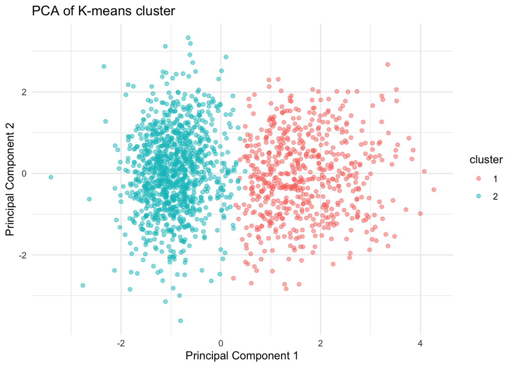

```r
# Performing PCA
pca_result <- prcomp(data_normalized)
data_pca <- as.data.frame(pca_result$x[,1:2])  # Keeping first two principal components

# Adding cluster assignments to PCA-reduced data
data_pca$cluster <- as.factor(kmeans_result$cluster)

# Plotting
ggplot(data_pca, aes(x=PC1, y=PC2, color=cluster)) +
  geom_point(alpha=0.5) +
  theme_minimal() +
  labs(title="PCA of K-means cluster", x="Principal Component 1", y="Principal Component 2")
```

The PCA plot shows the distribution of the data points in 2d space defined by the first two principal components, with points colored by their k-means cluster assignments. The clusters seem to be separated very well.

**PCA and K-Means Clustering**

```r
# Performing PCA on normalized data
pca_result <- prcomp(data_normalized, scale. = TRUE)
summary(pca_result)  # To see the importance of components
```

```
## Importance of components:
##                           PC1    PC2    PC3    PC4     PC5
## Standard deviation     1.3913 1.0125 0.9976 0.9854 0.26999
## Proportion of Variance 0.3872 0.2050 0.1990 0.1942 0.01458
## Cumulative Proportion  0.3872 0.5922 0.7912 0.9854 1.00000
```

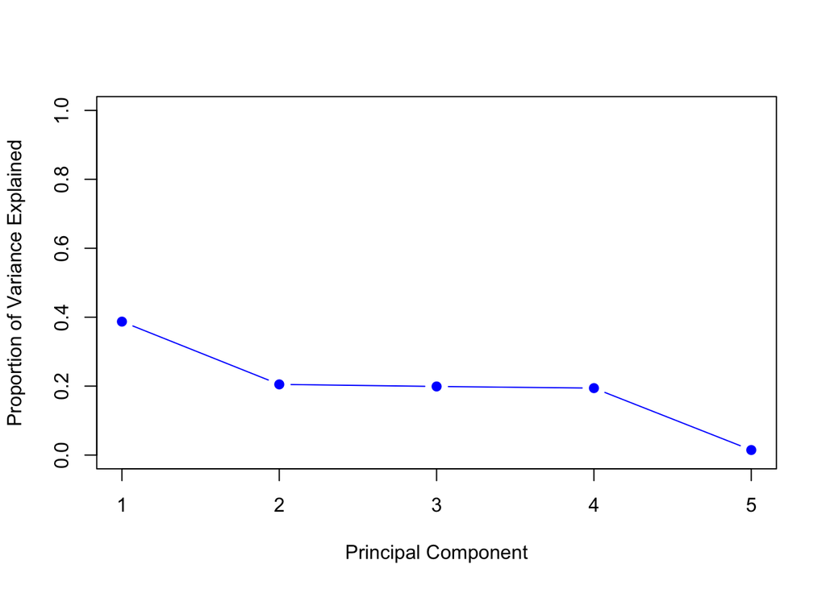

```r
# Extract the variance explained by each principal component
var_explained <- pca_result$sdev^2 / sum(pca_result$sdev^2)

# Create a Scree plot
plot(var_explained, ylim=c(0.0,1.0), xlab="Principal Component", ylab="Proportion of Variance Explained",
     type='b', pch=19, col="blue")
```

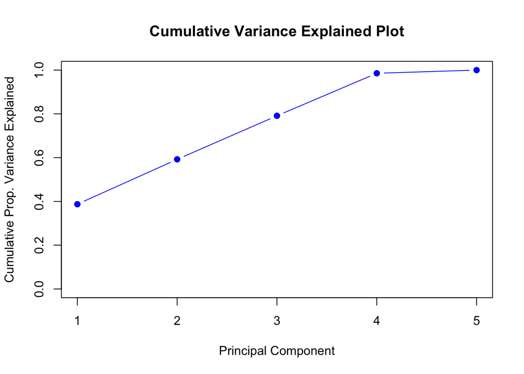

```r
cum_var_explained <- cumsum(var_explained)

# plot Cumulative Proportion of Variance Explained
plot(cum_var_explained, ylim=c(0.0,1.0), xlab="Principal Component", ylab="Cumulative Prop. Variance Explained",
     type='b', pch=19, col="blue", main="Cumulative Variance Explained Plot")
```

The summary of the PCA indicates that the first principal component (PC1) explains approximately 38.72% of the variance within the data, while the second component (PC2) accounts for an additional 20.50%. Together, PC1 and PC2 capture about 59.22% of the variance, indicating that these two components are the most significant in terms of explaining the variability in the dataset. PC5 contributes very little to the variance so we can ignore it.

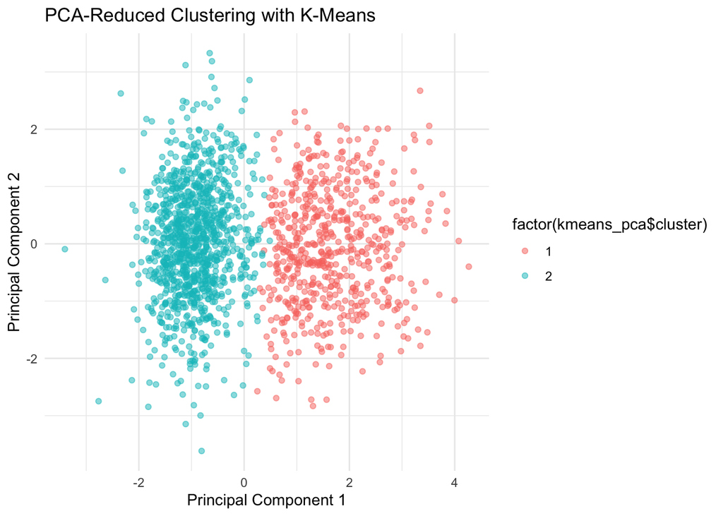

```r
# Choosing number of components to keep
var_explained <- cumsum(pca_result$sdev^2 / sum(pca_result$sdev^2))

# choosing the components that explain 95% of the variance
num_components <- which(var_explained >= 0.95)[1]
data_pca <- data.frame(pca_result$x[, 1:num_components])
names(data_pca) <- paste0("PC", 1:num_components)  # Naming the PCA columns

# Clustering on PCA-reduced data
set.seed(57)
kmeans_pca <- kmeans(data_pca, centers=2)

# Plotting the clusters based on the first two principal components
ggplot(data_pca, aes(x=PC1, y=PC2, color=factor(kmeans_pca$cluster))) +
  geom_point(alpha=0.5) +
  theme_minimal() +
  labs(title="PCA-Reduced Clustering with K-Means", x="Principal Component 1", y="Principal Component 2")
```

This PCA-reduced clustering plot closely resembles the earlier one, again displaying the data in two principal components with points color-coded by their cluster assignment.

**Hierarchical Clustering**

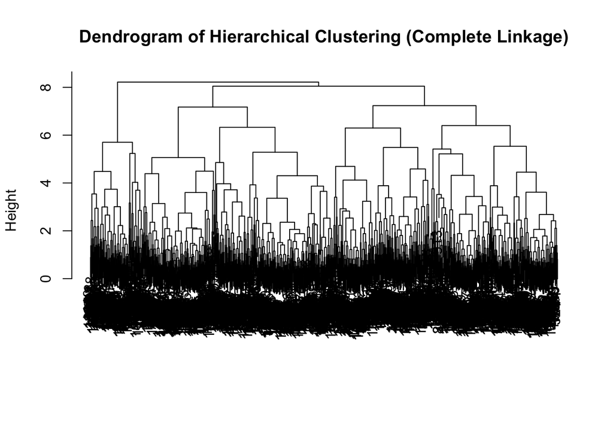

```r
### Performing Hierarchical Clustering

# Calculating distances between all pairs of samples
distances <- dist(data_normalized)

# Performing hierarchical clustering using complete linkage
hc.complete <- hclust(distances, method = "complete")

# Plotting the dendrogram
plot(hc.complete, main="Dendrogram of Hierarchical Clustering (Complete Linkage)", xlab="", sub="")
```

Because of the density of branches at the lower part of the dendrogram, it’s challenging to discern individual merges or determine clear clusters. Thus we will cut the dendogram.

**Cutting the Dendrogram to Form Clusters**

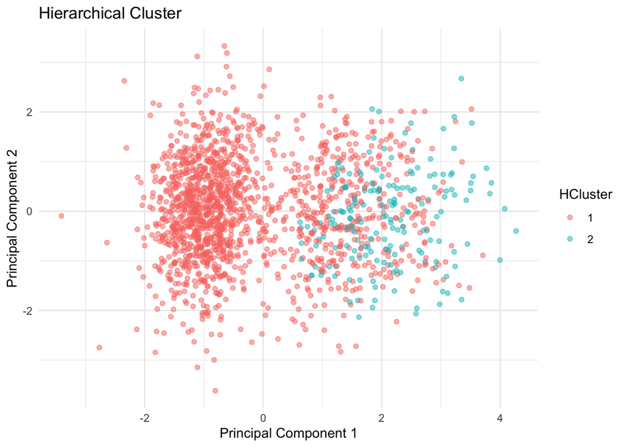

```r
# Cutting the dendrogram
clusters <- cutree(hc.complete, k=2)

# Mapping cluster membership back to the PCA-reduced data for visualization
data_pca$HCluster <- as.factor(clusters)

# Plotting
ggplot(data_pca, aes(x=PC1, y=PC2, color=HCluster)) +
  geom_point(alpha=0.5) +
  theme_minimal() +
  labs(title="Hierarchical Cluster", x="Principal Component 1", y="Principal Component 2")
```

This scatter plot displays the data points reduced to two principal components after performing PCA, with each point colored according to its hierarchical cluster assignment.

The clusters show some degree of separation, but there is some overlap indicating that the hierarchical clustering didn’t quite capture the difference in the data.

**Comparison of Clustering Methods**

```r
# Calculating silhouette width
# Silhouette score without PCA
sil_width_without_pca <- silhouette(kmeans_result$cluster, dist(data_normalized))
avg_sil_width_without_pca <- mean(sil_width_without_pca[, 3])
cat("Average Silhouette Width (without PCA): ", avg_sil_width_without_pca, "\n")
```

```
## Average Silhouette Width (without PCA):  0.3106597
```

```r
# Silhouette score with PCA
sil_width_with_pca <- silhouette(kmeans_result$cluster, dist(data_pca))
avg_sil_width_with_pca <- mean(sil_width_with_pca[, 3])
cat("Average Silhouette Width (with PCA): ", avg_sil_width_with_pca, "\n")
```

```
## Average Silhouette Width (with PCA):  0.3129486
```

```r
# Comparing cluster assignments from K-Means and Hierarchical Clustering
table(kmeans_pca$cluster, clusters)
```

```
##    clusters
##        1    2
##   1  414  190
##   2 1071    0
```

This table compares the cluster assignments obtained from K-Means and Hierarchical Clustering methods when each method has been asked to identify two clusters within the same dataset.

- The majority of the data points in cluster 1 from the K-Means algorithm were also placed in cluster 1 by the Hierarchical Clustering algorithm (414 out of 604).
- Cluster 2 from K-Means is entirely classified into cluster 1 by Hierarchical Clustering with all 1071 points.

**Evaluating Hierarchical Clustering**

```r
# Calculating silhouette width for hierarchical clustering
sil_width_hc <- silhouette(clusters, distances)
avg_sil_width_hc <- mean(sil_width_hc[, 3])
cat("Average Silhouette Width (Hierarchical - Complete Linkage): ", avg_sil_width_hc, "\n")
```

```
## Average Silhouette Width (Hierarchical - Complete Linkage):  0.1979312
```

The silhouette width for the Hierarchical clustering is significantly lower than for the K-means.

## 1.3 Conclusion

In this analysis, we applied K-means clustering to both the original and PCA-reduced datasets. The PCA approach did not show any difference from the original one, as evidenced by similiar silhouette scores.

We also note that the K-means classifier gets better Silhoutte score than the Hierarchical clustering.

# 2 Part 2: Prediction / Inference

In this section, we explore prediction models using a dataset derived from proteomics measurements. The dataset, `proteomics_dube_2023.csv`, contains plasma protein levels across 1,462 proteins for 40 samples, taken from 10 subjects under different acclimation stages and thermal states.

**Data Preparation**

```r
# Loading libraries
library(caret)
library(randomForest)
library(nnet)

# Reading and viewing the dataset
proteomics_data <- read_csv("proteomics_dube_2023.csv")
view(proteomics_data)
```

```r
# Checking for missing values
sum(is.na(proteomics_data))
```

```
## [1] 0
```

There are none missing values

## 2.1 i. Quantitative Prediction

We aim to predict a specific protein level using other protein levels in the dataset, applying both linear and non-linear models to compare their effectiveness.

**Loading Libraries and Data Preparation**

```r
# Load necessary libraries
library(caret)
library(randomForest)
library(dplyr)

# Read the data
proteomics_data <- read.csv("proteomics_dube_2023.csv")

# Remove non-numeric columns
proteomics_data <- proteomics_data %>%
  select(-SubjectID, -temp, -acclimation)

# Scale the data
proteomics_data <- scale(proteomics_data)
proteomics_data <- as.data.frame(proteomics_data)
colnames(proteomics_data) <- make.names(colnames(proteomics_data))
```

**Creating Training and Testing Sets**

```r
# Choosing a target variable
target_variable <- "ITGAL"

# Create training and testing datasets
set.seed(42)

index <- createDataPartition(proteomics_data[[target_variable]], p = 0.8, list = FALSE)
train_data <- proteomics_data[index, ]
test_data <- proteomics_data[-index, ]
```

We partition the data into training and testing sets to evaluate model performance.

- I chose the ITGAL protein to be the target variable for the prediction model.

**Model Setup and Cross-Validation**

```r
# Set up cross-validation
control <- trainControl(method = "cv", number = 10, savePredictions = "final")

# Initializing models with cross-validation
models_to_train <- c("Linear" = "lm", "Random Forest" = "rf")
model_forms <- sapply(models_to_train, function(model) {
  reformulate(colnames(train_data)[-which(colnames(train_data) == target_variable)], target_variable)
})
```

**training Models**

```r
# Linear Regression Model with Cross-Validation
linear_model_cv <- train(model_forms[["Linear"]], data = train_data, method = "lm", trControl = control)

# Random Forest Model with Cross-Validation
rf_model_cv <- train(model_forms[["Random Forest"]], data = train_data, method = "rf", trControl = control, tuneLength = 5)
```

Here we train both linear regression model and random forest model

**evaluating Model Performance**

```r
# results from models
results <- resamples(list(Linear = linear_model_cv, RF = rf_model_cv))
summary(results)
```

```
##
## Call:
## summary.resamples(object = results)
##
## Models: Linear, RF
## Number of resamples: 10
##
## MAE
##             Min.   1st Qu.     Median      Mean  3rd Qu.      Max. NA's
## Linear 3.2471242 6.9681207 10.0627128 9.8805169 12.28600 16.370471    0
## RF     0.7821608 0.8578537  0.9648348 0.9802935  1.04337  1.312068    0
##
## RMSE
##             Min.   1st Qu.     Median      Mean  3rd Qu.      Max. NA's
## Linear 4.4524705 8.5926022 10.8162713 11.614473 15.50551 18.492944    0
## RF     0.8364787 0.9295519  0.9872787  1.019316  1.04779  1.349782    0
##
## Rsquared
##               Min.    1st Qu.    Median      Mean   3rd Qu. Max. NA's
## Linear 0.001243186 0.48834028 0.7355272 0.6539009 0.9923885    1    0
## RF     0.001467600 0.08381244 0.3801524 0.4757344 0.8776101    1    0
```

to summarize

> Mean Absolute Error (MAE):

> > Linear Model: The MAE ranged from about 3.25 to 16.37, with an average error of about 9.88.

> > Random Forest Model: The RF model performed much better, with errors ranging from about 0.78 to 1.31, and an average of just about 0.98 units. This model is more accurate in its predictions.

> Root Mean Squared Error (RMSE):

> > Linear Model: The RMSE for the Linear model was higher, ranging from 4.45 to 18.49, with an average of 11.61.

> > Random Forest Model: The RF model again shows better performance, with RMSE values from about 0.84 to 1.35, averaging 1.02, suggesting its predictions are generally closer to the true values.

> R-squared:

> > Linear Model: R-squared values for the Linear model varied a lot, from nearly 0.00 to 1.00, with an average of about 0.65.

> > An important point is that in such a high dimentional data the R-squered value should be taken with a grain of salt.

**Visualization of Predictions**

Some visualizations of the errors.

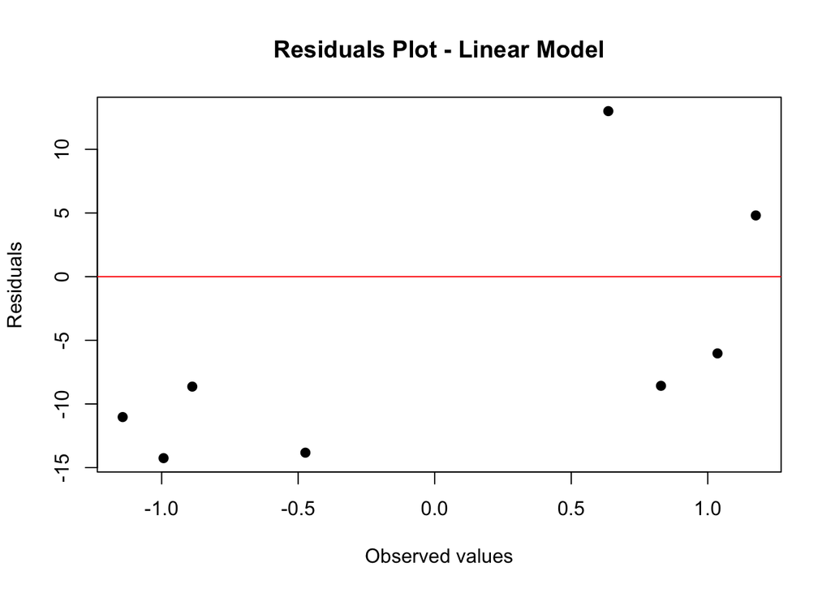

```r
# Plotting residuals for Linear Model
linear_residuals <- test_data$ITGAL - predict(linear_model_cv, test_data)
plot(test_data$ITGAL, linear_residuals, main = "Residuals Plot - Linear Model",
     xlab = "Observed values", ylab = "Residuals", pch = 19)
abline(h = 0, col = "red")
```

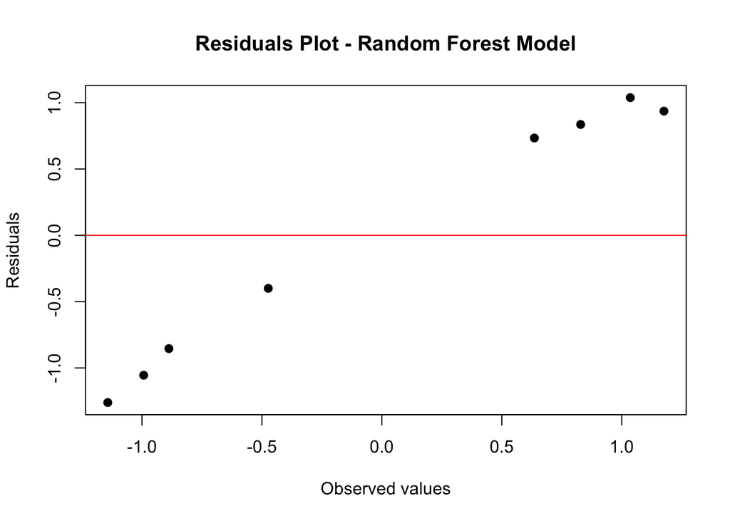

```r
# Plotting residuals for Random Forest Model
rf_residuals <- test_data$ITGAL - predict(rf_model_cv, test_data)
plot(test_data$ITGAL, rf_residuals, main = "Residuals Plot - Random Forest Model",
     xlab = "Observed values", ylab = "Residuals", pch = 19)
abline(h = 0, col = "red")
```

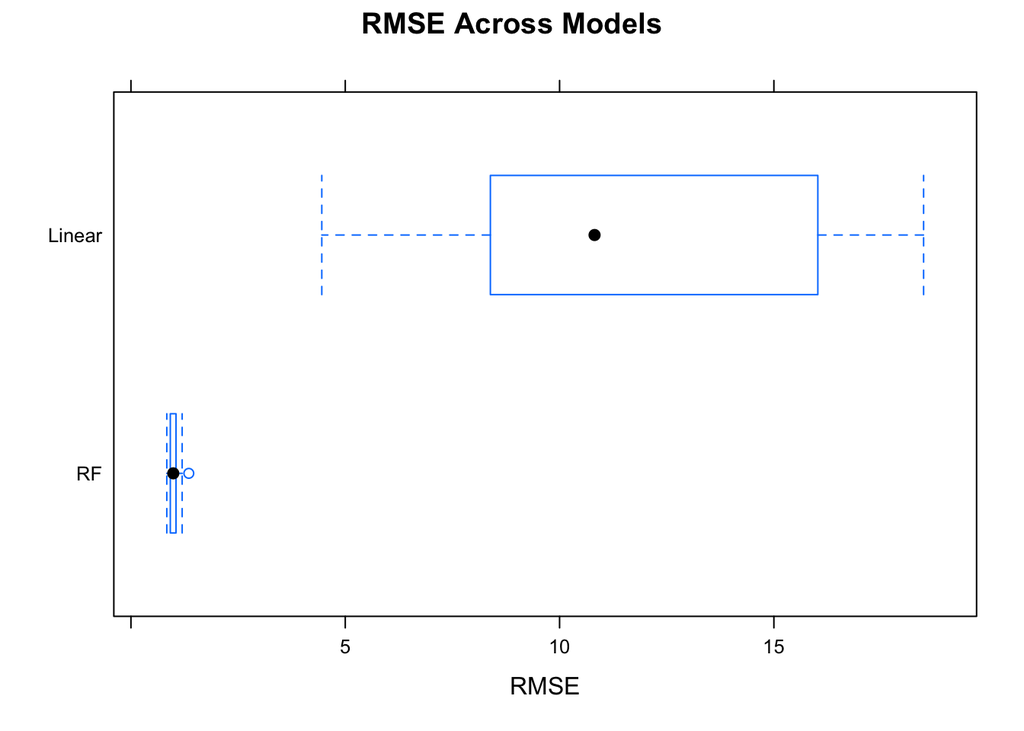

```r
# Boxplot of RMSE
bwplot(results, metric = "RMSE", main = "RMSE Across Models")
```

**Short Comment on the Models**

I wanted to look at both a linear model and a model that could handle non linearity. That is the reason why I looked at linear regression and random forest.

An obvious weakness of the linear regression model is that it can’t handle non linearity.

## 2.2 ii. Categorical Prediction

Next, we create a binary target variable and employ different classification methods to predict it.

**Loading Libraries and Data**

```r
# Load libraries
library(e1071)  # For SVM
library(class) # For k-NN

set.seed(7)

# Read the data
proteomics_data <- read.csv("proteomics_dube_2023.csv")
```

**Data Preparation**

```r
# Seed
set.seed(43)

# training and testing sets
data_partition <- createDataPartition(y = proteomics_data$temp, p = 0.7, list = FALSE)
train_set <- proteomics_data[data_partition, ]
test_set <- proteomics_data[-data_partition, ]
```

**Model Training**

```r
# cross-validation
cv_control <- trainControl(method = "cv", number = 10)  # 10-fold cross-validation

# Training a Support Vector Machine with Radial Kernel
svm_model <- train(temp ~ ., data = train_set, method = "svmRadial",
                   trControl = cv_control, tuneLength = 10)

# Training a k-NN model
knn_model <- train(temp ~ ., data = train_set, method = "knn",
                   trControl = cv_control, tuneLength = 10)
```

**Model Performance Comparison**

```r
# Comparing the performance of the SVM, and k-NN models
model_comparisons <- resamples(list(SVM_Radial = svm_model,
                                    KNN = knn_model))

comparison_summary <- summary(model_comparisons)
print(comparison_summary)
```

```
##
## Call:
## summary.resamples(object = model_comparisons)
##
## Models: SVM_Radial, KNN
## Number of resamples: 10
##
## Accuracy
##                 Min. 1st Qu.    Median      Mean   3rd Qu. Max. NA's
## SVM_Radial 0.3333333   0.500 0.6666667 0.6416667 0.7291667    1    0
## KNN        0.3333333   0.375 0.6666667 0.6833333 1.0000000    1    0
##
## Kappa
##            Min. 1st Qu. Median Mean 3rd Qu. Max. NA's
## SVM_Radial -0.5       0    0.2 0.28   0.475    1    0
## KNN         0.0       0    0.4 0.48   1.000    1    0
```

After doing 10-fold cross validation we got these results:

- SVM_Radial had scores as low as about 33% which is worse than random, but sometimes it did much better, up to 100%. On average, it got about 64% right.
- KNN did a better job at classifying, with kappa scores starting at 0 (just random guessing) but averaging out at 0.48, which means it’s doing a better job than SVM in making guesses that aren’t just by chance.

**Model Evaluation on Test Data**

```r
svm_predictions_raw <- predict(svm_model, test_set)
knn_predictions_raw <- predict(knn_model, test_set)

all_possible_levels <- c("hyperthermic", "normothermic")


test_set$temp <- factor(test_set$temp, levels = all_possible_levels)
svm_predictions <- factor(svm_predictions_raw, levels = all_possible_levels)
knn_predictions <- factor(knn_predictions_raw, levels = all_possible_levels)

# Confusion matrices
svm_accuracy <- confusionMatrix(svm_predictions, test_set$temp)
knn_accuracy <- confusionMatrix(knn_predictions, test_set$temp)

# Accuracy Results
print("SVM Accuracy:")
```

```
## [1] "SVM Accuracy:"
```

```r
print(svm_accuracy)
```

```
## Confusion Matrix and Statistics
##
##               Reference
## Prediction     hyperthermic normothermic
##   hyperthermic            3            1
##   normothermic            3            5
##
##                Accuracy : 0.6667
##                  95% CI : (0.3489, 0.9008)
##     No Information Rate : 0.5
##     P-Value [Acc > NIR] : 0.1938
##
##                   Kappa : 0.3333
##
##  Mcnemar's Test P-Value : 0.6171
##
##             Sensitivity : 0.5000
##             Specificity : 0.8333
##          Pos Pred Value : 0.7500
##          Neg Pred Value : 0.6250
##              Prevalence : 0.5000
##          Detection Rate : 0.2500
##    Detection Prevalence : 0.3333
##       Balanced Accuracy : 0.6667
##
##        'Positive' Class : hyperthermic
##
```

```r
print("KNN Accuracy:")
```

```
## [1] "KNN Accuracy:"
```

```r
print(knn_accuracy)
```

```
## Confusion Matrix and Statistics
##
##               Reference
## Prediction     hyperthermic normothermic
##   hyperthermic            3            0
##   normothermic            3            6
##
##                Accuracy : 0.75
##                  95% CI : (0.4281, 0.9451)
##     No Information Rate : 0.5
##     P-Value [Acc > NIR] : 0.0730
##
##                   Kappa : 0.5
##
##  Mcnemar's Test P-Value : 0.2482
##
##             Sensitivity : 0.5000
##             Specificity : 1.0000
##          Pos Pred Value : 1.0000
##          Neg Pred Value : 0.6667
##              Prevalence : 0.5000
##          Detection Rate : 0.2500
##    Detection Prevalence : 0.2500
##       Balanced Accuracy : 0.7500
##
##        'Positive' Class : hyperthermic
##
```

General takeaways

$\textbf{SVM Model:}$

- Classifyied about 67% correctly which is better than random
- The sensitivity being 50% meaning that identified 50% of the hyperthermic samples. But the specificity was much higher or around 83.33% meaning that it correctly classifyied most of the normothermic samples.

**Visualisation**

[figure not shown]

```r
library(yardstick)
library(ggplot2)

svm_data <- data.frame(truth = test_set$temp, estimate = svm_predictions)
knn_data <- data.frame(truth = test_set$temp, estimate = knn_predictions)

# confusion matrices
svm_cm <- conf_mat(svm_data, truth = truth, estimate = estimate)
knn_cm <- conf_mat(knn_data, truth = truth, estimate = estimate)

# Plot SVM Confusion Matrix
svm_plot <- autoplot(svm_cm, type = "heatmap") +
  scale_fill_gradient(low = "#D6EAF8", high = "#2E86C1") +
  labs(title = "SVM Confusion Matrix", x = "Predicted", y = "Actual") +
  theme_minimal() +
  theme(axis.text = element_text(size = 12),
        axis.title = element_text(size = 14, face = "bold"))

# Plot KNN Confusion Matrix
knn_plot <- autoplot(knn_cm, type = "heatmap") +
  scale_fill_gradient(low = "#D6EAF8", high = "#2E86C1") +
  labs(title = "KNN Confusion Matrix", x = "Predicted", y = "Actual") +
  theme_minimal() +
  theme(axis.text = element_text(size = 12),
        axis.title = element_text(size = 14, face = "bold"))

print(svm_plot)
```

[figure not shown]

```r
print(knn_plot)
```

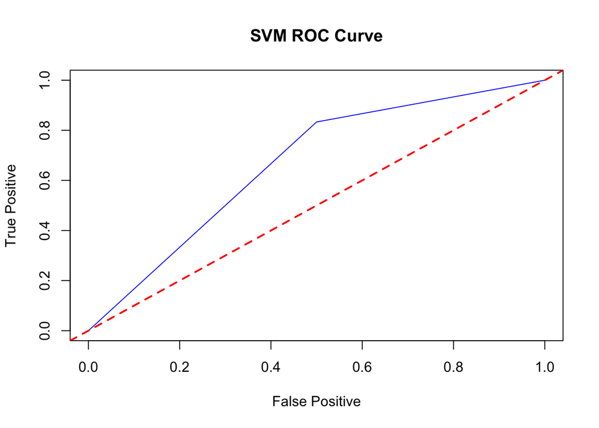

```
## AUC: 0.6666667
```

```r
library(ROCR)

plot_roc_curve_rocr <- function(predictions, truth, title) {

    pred <- prediction(predictions, truth)

    # Calculating performance
    perf <- performance(pred, "tpr", "fpr")

    # Plotting the ROC curve
    plot(perf, main = title, col = "blue", xlab = "False Positive", ylab = "True Positive")

    abline(a = 0, b = 1, col = "red", lwd = 2, lty = 2)

    # Calculating AUC
    auc <- performance(pred, measure = "auc")
    auc_value <- auc@y.values[[1]]
    cat("AUC:", auc_value, "\n")  # Print AUC value

    return(list(roc = perf, auc = auc_value))
}


svm_predictions_numeric <- as.numeric(svm_predictions) - 1
knn_predictions_numeric <- as.numeric(knn_predictions) - 1


truth_numeric <- as.numeric(test_set$temp) - 1

# Plot ROC curves
svm_roc_results <- plot_roc_curve_rocr(svm_predictions_numeric, truth_numeric, "SVM ROC Curve")
```

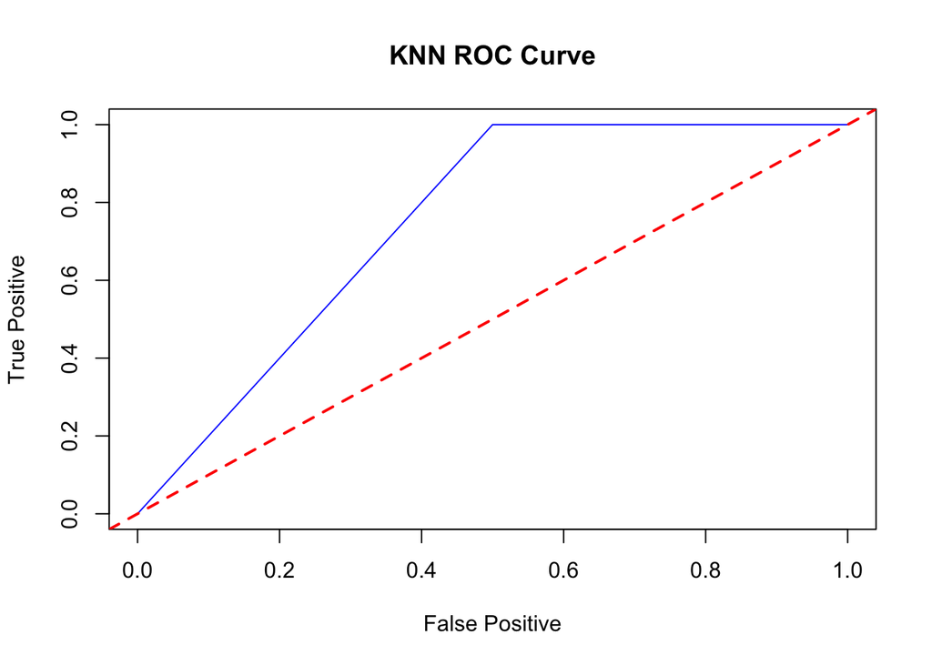

```
## AUC: 0.75
```

```r
knn_roc_results <- plot_roc_curve_rocr(knn_predictions_numeric, truth_numeric, "KNN ROC Curve")
```

An important observation is that although KNN can struggle in high-dimensional spaces it still managed to make a fairly good prediction model. The KNN even did a better job than the SVM although SVM is often better in high dimensional spaces.

I also tried to fit a logistical classifier but it didn’t fit the data well.

I chose to look at SVM because the data we have is fairly high in dimension and SVM tend to perform well in high dimensional data.